# Assignment - Week 08

Flurin Schindele

2026-04-28

```r
suppressPackageStartupMessages({
  library(epiwraps)
  library(ggplot2)
  library(AnnotationHub)
  library(ensembldb)
  library(rtracklayer)
  library(GenomicRanges)
  library(GenomeInfoDb)
  # library(edgeR)
  library(BiocParallel)
  library(bsseq)   # Class and tools to analyze bisulfite sequencing data at CpG-level
  library(DMRcate) # Identification of differentially-methylated regions
})
```

# Plotting DNAme of genes in top 5 DMR

We first load the differentially methylation region data, as well as BSseq object containing the methlyation signal. We also apply smoothing like in the tutorial.

```r
dmr <- readRDS("data/dmr.rds")
head(dmr)
```

```
## GRanges object with 6 ranges and 8 metadata columns:
##       seqnames              ranges strand |   no.cpgs min_smoothed_fdr
##          <Rle>           <IRanges>  <Rle> | <integer>        <numeric>
##   [1]    chr19     2250311-2253429      * |        94                0
##   [2]    chr13 109792493-109793503      * |        79                0
##   [3]     chr8     9008196-9009307      * |        79                0
##   [4]    chr19   48945963-48947530      * |        75                0
##   [5]    chr11       279433-280820      * |        54                0
##   [6]    chr10 105344239-105344830      * |        53                0
##           Stouffer       HMFDR       Fisher   maxdiff  meandiff
##          <numeric>   <numeric>    <numeric> <numeric> <numeric>
##   [1]  0.00000e+00 6.03664e-11  0.00000e+00 -10.42893  -6.31410
##   [2]  0.00000e+00 1.76954e-09  0.00000e+00  -9.34866  -5.93610
##   [3] 6.21016e-213 3.22005e-10 2.32673e-292  -9.80840  -4.60163
##   [4]  0.00000e+00 1.08552e-10  0.00000e+00 -10.35454  -6.17428
##   [5]  0.00000e+00 2.22515e-11 2.08002e-321 -10.75389  -6.94192
##   [6]  0.00000e+00 1.35440e-10  0.00000e+00 -10.29849  -7.10243
##           overlapping.genes
##                 <character>
##   [1]   AMH, MIR4321, JSRP1
##   [2]                 MYO16
##   [3] RP11-10A14.4, PPP1R3B
##   [4]                GRIN2D
##   [5]                 NLRP6
##   [6]                NEURL1
##   -------
##   seqinfo: 23 sequences from an unspecified genome; no seqlengths
```

```r
if (!file.exists("data/ESC_astrocytes_BSseq_smoothed.rds")) {
  bs <- readRDS("data/ESC_astrocytes_BSseq.rds")
  bs <- bs[rowSums(assay(bs,"Cov")>0)==ncol(bs),]
  bs <- BSmooth(bs, BPPARAM=MulticoreParam(4, progress=FALSE))
  saveRDS(bs, "data/ESC_astrocytes_BSseq_smoothed.rds")
} else {
  bs <- readRDS("data/ESC_astrocytes_BSseq_smoothed.rds")
}
bs
```

```
## An object of type 'BSseq' with
##   732301 methylation loci
##   4 samples
## has been smoothed with
##   BSmooth (ns = 70, h = 1000, maxGap = 100000000)
## All assays are in-memory
```

We subset to chromosome 1 and select the top 5 DMRs by HMFDR, then find genes that overlap these regions and plot their methylation levels across samples.

```r
# get regions from chromosome 1
roi <- dmr[seqnames(dmr) == "chr1"]
roi <- roi[order(roi$HMFDR)][1:5]
head(roi)
```

```
## GRanges object with 5 ranges and 8 metadata columns:
##       seqnames              ranges strand |   no.cpgs min_smoothed_fdr
##          <Rle>           <IRanges>  <Rle> | <integer>        <numeric>
##   [1]     chr1 207818394-207818642      * |        19     2.24056e-271
##   [2]     chr1 240160779-240161545      * |        47      0.00000e+00
##   [3]     chr1   16501666-16502614      * |         7      2.32640e-71
##   [4]     chr1     8181186-8181267      * |         6      1.68474e-70
##   [5]     chr1 209404930-209405333      * |        36     1.32349e-256
##           Stouffer       HMFDR       Fisher   maxdiff  meandiff
##          <numeric>   <numeric>    <numeric> <numeric> <numeric>
##   [1] 2.50626e-186 1.87459e-12 2.35612e-178  -11.5620  -9.18854
##   [2]  0.00000e+00 3.04297e-12  0.00000e+00  -11.4976  -8.85801
##   [3]  6.58680e-54 5.96387e-12  8.04731e-53  -10.8889  -7.81695
##   [4]  1.51441e-52 8.28376e-12  2.44424e-50  -10.7083  -8.42763
##   [5] 4.88222e-199 2.42465e-11 1.62600e-192  -10.6237  -6.47723
##       overlapping.genes
##             <character>
##   [1]      CR1L, CD46P1
##   [2]              <NA>
##   [3]              <NA>
##   [4]     RP11-431K24.1
##   [5]              <NA>
##   -------
##   seqinfo: 23 sequences from an unspecified genome; no seqlengths
```

```r
# get genes that overlap regions of interest
genes <- readRDS("data/hg19_chr1_genes.rds")
genes_oi <- subsetByOverlaps(genes, roi, ignore.strand=TRUE, type="any")
genes_oi
```

```
## GRanges object with 1 range and 2 metadata columns:
##        seqnames              ranges strand |     gene_id      symbol
##           <Rle>           <IRanges>  <Rle> | <character> <character>
##   CR1L     chr1 207818458-207898053      + |        1379        CR1L
##   -------
##   seqinfo: 93 sequences (1 circular) from hg19 genome
```

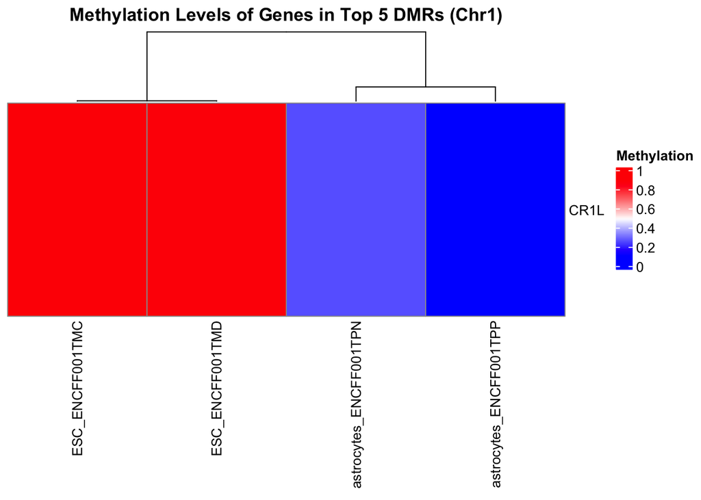

```r
metROI <- bsseq::getMeth(bs, regions=genes_oi, what="perRegion")
rownames(metROI) <- genes_oi$symbol

pheatmap(metROI,
         name = "Methylation",
         main = "Methylation Levels of Genes in Top 5 DMRs (Chr1)",
         show_rownames = TRUE,
         color = colorRampPalette(c("blue", "white", "red"))(50))
```

Interestingly, this approach only shows on gene. The top 5 DMRs also show 2 other genes but they were not found in the hg19 genes. We will try again with a larger set of DMRs.

```r
# get regions from chromosome 1
roi20 <- dmr[seqnames(dmr) == "chr1"]
roi20 <-roi20[order(roi20$HMFDR)][1:20]
tail(roi20)
```

```
## GRanges object with 6 ranges and 8 metadata columns:
##       seqnames              ranges strand |   no.cpgs min_smoothed_fdr
##          <Rle>           <IRanges>  <Rle> | <integer>        <numeric>
##   [1]     chr1   33235515-33235798      * |        16      1.83495e-15
##   [2]     chr1   25240876-25240995      * |        10      1.56277e-84
##   [3]     chr1   31280121-31280510      * |        21     1.68260e-109
##   [4]     chr1 149156293-149156353      * |         8      3.62261e-88
##   [5]     chr1     8014259-8014328      * |        13     2.75125e-143
##   [6]     chr1     2005142-2005485      * |        11     6.37020e-106
##           Stouffer       HMFDR       Fisher   maxdiff  meandiff
##          <numeric>   <numeric>    <numeric> <numeric> <numeric>
##   [1]  1.06995e-03 8.41545e-11  1.75255e-08  10.03342  0.101418
##   [2]  7.62005e-68 1.59597e-10  3.02975e-64  -9.77504 -7.242386
##   [3]  1.04609e-72 2.10113e-10  1.34512e-77 -10.03177 -5.185964
##   [4]  7.85639e-66 2.18725e-10  2.40460e-62  -9.42424 -8.033066
##   [5] 1.14628e-109 2.25872e-10 2.27910e-103  -9.42376 -8.158367
##   [6]  1.80748e-82 2.31431e-10  3.26148e-78  -9.48123 -7.606945
##       overlapping.genes
##             <character>
##   [1]          KIAA1522
##   [2]             RUNX3
##   [3]              <NA>
##   [4]              <NA>
##   [5]              <NA>
##   [6]             PRKCZ
##   -------
##   seqinfo: 23 sequences from an unspecified genome; no seqlengths
```

```r
# get genes that overlap regions of interest
genes_oi20 <- subsetByOverlaps(genes, roi20, ignore.strand=TRUE, type="any")
genes_oi20$symbol
```

```
##  [1] "PRKCZ"    "DRAXIN"   "KIAA1522" "MAP7D1"   "RNF220"   "ELF3"
##  [7] "CR1L"     "TRIM58"   "TTC34"    "RUNX3"    "C1orf198"
```

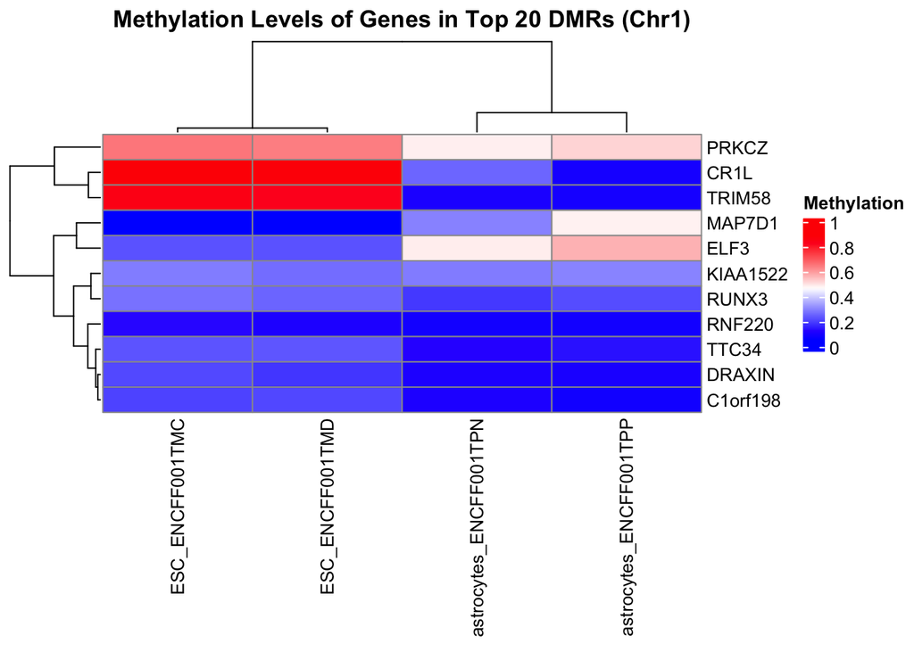

```r
metROI20 <- bsseq::getMeth(bs, regions=genes_oi20, what="perRegion")
rownames(metROI20) <- genes_oi20$symbol

pheatmap(metROI20,
         name = "Methylation",
         main = "Methylation Levels of Genes in Top 20 DMRs (Chr1)",
         show_rownames = TRUE,
         color = colorRampPalette(c("blue", "white", "red"))(50))
```

The first few regions show very distinct methylation profiles between conditions witih ESCs showing higher methylation levels than astrocytes.

# Agreement between DNAme and ATAC

We first load the data and then rebuild the object as there seems to be some bug present.

```r
atac_path <- "data/ATAC_AstroVsESC_subset.rds"
if (!file.exists(atac_path)) {
  download.file(
    "https://www.ethz-ins.org/content/ATAC_AstroVsESC_subset.rds",
    destfile = atac_path,
    mode = "wb"
  )
}
atac_da_raw <- readRDS(atac_path)

# Rebuild as a plain GRanges to avoid legacy Seqinfo class issues across Bioc versions.
atac_df <- as.data.frame(atac_da_raw)
atac_da <- GRanges(
  seqnames = atac_df$seqnames,
  ranges = IRanges(atac_df$start, atac_df$end),
  strand = atac_df$strand
)
mcols(atac_da) <- S4Vectors::DataFrame(
  atac_df[, setdiff(colnames(atac_df), c("seqnames", "start", "end", "width", "strand")), drop=FALSE]
)
atac_da
```

```
## GRanges object with 5279 ranges and 4 metadata columns:
##          seqnames              ranges strand |       logFC    logCPM
##             <Rle>           <IRanges>  <Rle> |   <numeric> <numeric>
##      [1]     chr3   32911212-32911472      * |    -14.5380   2.57720
##      [2]     chr8     9007982-9008485      * |    -13.6671   1.65566
##      [3]     chr3   57164721-57165102      * |    -15.0043   3.05803
##      [4]    chr22   46476146-46476721      * |     14.1114   1.44761
##      [5]     chr1   23763045-23763443      * |    -14.5437   2.58018
##      ...      ...                 ...    ... .         ...       ...
##   [5275]     chr5 137577769-137578048      * | -0.00242190  0.245626
##   [5276]    chr16   88219895-88220191      * | -0.00216304 -2.417734
##   [5277]    chr16     1244671-1245087      * | -0.00162255 -0.354065
##   [5278]    chr15 101084756-101085159      * | -0.00159517 -1.856909
##   [5279]    chr20   55965076-55965583      * |  0.00107086  0.386627
##                PValue          FDR
##             <numeric>    <numeric>
##      [1] 1.84223e-185 1.22824e-180
##      [2] 6.70803e-143 4.25568e-139
##      [3] 6.19768e-137 3.09624e-133
##      [4] 5.26376e-134 2.32832e-130
##      [5] 1.99867e-133 8.57188e-130
##      ...          ...          ...
##   [5275]     0.991248     0.993925
##   [5276]     0.993230     0.995311
##   [5277]     0.994525     0.996176
##   [5278]     0.994613     0.996245
##   [5279]     0.995914     0.997130
##   -------
##   seqinfo: 24 sequences from an unspecified genome; no seqlengths
```

We then query the gene annotations from Ensembl, subset to protein-coding genes, and define promoter and gene body regions. We will then compare the DMRs and ATAC peaks that overlap these regions, and compute agreement metrics.

```r
ah <- AnnotationHub()
ensdb <- ah[["AH119325"]]
```

```
## loading from cache
```

```r
genes <- genes(ensdb)[genes(ensdb)$gene_biotype == "protein_coding"]
genes <- keepStandardChromosomes(genes, pruning.mode="coarse")
seqlevelsStyle(genes) <- "UCSC"

promoters <- promoters(genes, upstream=2000, downstream=500)
gene_bodies <- genes
```

All ATAC peaks overlap with DMRs and roughly 97% of DMRs overlap with ATAC peaks, which is a very high degree of overlap.

```r
prop_overlap <- function(query_peaks, subject_peaks) {
  mean(overlapsAny(query_peaks, subject_peaks))
}
prop_overlap(atac_da, dmr)
```

```
## [1] 1
```

```r
prop_overlap(dmr, atac_da)
```

```
## [1] 0.9763566
```

```r
summarize_region_agreement <- function(region_gr, region_label, dmr_gr, atac_gr) {
  # first get signals that overlap the regions of interest (promoters or gene bodies)
  dmr_sub <- subsetByOverlaps(dmr_gr, region_gr, ignore.strand=TRUE)
  atac_sub <- subsetByOverlaps(atac_gr, region_gr, ignore.strand=TRUE)
  # we also get the overlaps between the DMRs and ATAC peaks to compare their signal directly
  ov <- findOverlaps(dmr_sub, atac_sub, ignore.strand=TRUE)

  if (length(ov) == 0) {
    return(list(
      comp = data.frame(),
      metrics = data.frame(
        region_type = region_label,
        overlap_coefficient_pct = NA_real_,
        pearson_cor = NA_real_,
        spearman_cor = NA_real_
      )
    ))
  }

  ov_df <- data.frame(
    dmr_ix = queryHits(ov),
    # get mean difference in methylation and HMFDR for the DMRs that overlap ATAC peaks
    dmr_meandiff = dmr_sub$meandiff[queryHits(ov)],
    dmr_HMFDR = dmr_sub$HMFDR[queryHits(ov)],
    # get logFC and FDR for the ATAC peaks that overlap DMRs
    atac_logFC = atac_sub$logFC[subjectHits(ov)],
    atac_FDR = atac_sub$FDR[subjectHits(ov)]
  )

  dmr_comp <- data.frame(
    dmr_ix = as.integer(names(tapply(ov_df$atac_logFC, ov_df$dmr_ix, mean, na.rm=TRUE))),
    # extract mean atac logFC for each DMR by averaging across all overlapping ATAC peaks
    atac_logFC_mean = as.numeric(tapply(ov_df$atac_logFC, ov_df$dmr_ix, mean, na.rm=TRUE)),
    atac_FDR_min = as.numeric(tapply(ov_df$atac_FDR, ov_df$dmr_ix, min, na.rm=TRUE)),
    n_atac_peaks = as.integer(table(ov_df$dmr_ix))
  )

  dmr_comp$dmr_meandiff <- dmr_sub$meandiff[dmr_comp$dmr_ix]
  dmr_comp$dmr_HMFDR <- dmr_sub$HMFDR[dmr_comp$dmr_ix]
  dmr_comp$region_type <- region_label
  # If both methylation and accessibility changes are in the same direction (both positive or both negative), we call it "agree", otherwise "disagree"
  dmr_comp$signal_change <- ifelse(sign(dmr_comp$dmr_meandiff) == sign(dmr_comp$atac_logFC_mean),
                               "agree", "disagree")

  # Calculate both pearson and spearman correlation between methylation changes and mean ATAC logFC across overlapping regions
  corr_pearson <- cor(dmr_comp$dmr_meandiff, dmr_comp$atac_logFC_mean, method="pearson")
  corr_spearman <- cor(dmr_comp$dmr_meandiff, dmr_comp$atac_logFC_mean, method="spearman")

  list(
    comp = dmr_comp,
    metrics = data.frame(
      region_type = region_label,
      pearson_cor = corr_pearson,
      spearman_cor = corr_spearman
    )
  )
}

promoter_res <- summarize_region_agreement(promoters, "Promoters", dmr, atac_da)
gene_body_res <- summarize_region_agreement(gene_bodies, "Gene bodies", dmr, atac_da)
region_comp <- rbind(promoter_res$comp, gene_body_res$comp)

region_comp$signal_change <- factor(region_comp$signal_change, levels=c("agree", "disagree"))
region_comp$region_type <- factor(region_comp$region_type, levels=c("Promoters", "Gene bodies"))
region_comp
```

| dmr_ix | atac_logFC_mean | atac_FDR_min | n_atac_peaks | dmr_meandiff | dmr_HMFDR | region_type | signal_change |
| --- | --- | --- | --- | --- | --- | --- | --- |
| 1 | 6.864548905 | 1.838702e-24 | 3 | -8.3264870 | 1.268093e-11 | Promoters | disagree |
| 2 | 1.208929578 | 4.052006e-12 | 3 | -9.6751767 | 2.573282e-13 | Promoters | disagree |
| 3 | -9.017331982 | 2.714555e-55 | 4 | -3.7818487 | 2.215963e-08 | Promoters | agree |
| 4 | 4.034830314 | 5.063770e-88 | 5 | -5.1136683 | 6.806961e-11 | Promoters | disagree |
| 5 | 2.017379463 | 3.087123e-18 | 2 | -5.4756881 | 1.324723e-08 | Promoters | disagree |
| 6 | 5.649890154 | 2.437061e-50 | 3 | -4.6492010 | 1.538558e-09 | Promoters | disagree |
| 7 | 0.475559703 | 4.955220e-05 | 3 | -3.8774590 | 3.091057e-08 | Promoters | disagree |
| 8 | 0.781051315 | 1.946343e-05 | 1 | -4.9326275 | 2.558591e-09 | Promoters | disagree |
| 9 | 7.802936541 | 2.882621e-46 | 5 | -7.2382626 | 4.711457e-10 | Promoters | disagree |
| 10 | -0.635440291 | 1.123474e-03 | 2 | -9.4269243 | 1.030130e-12 | Promoters | agree |

[output cut: 1481 more lines]

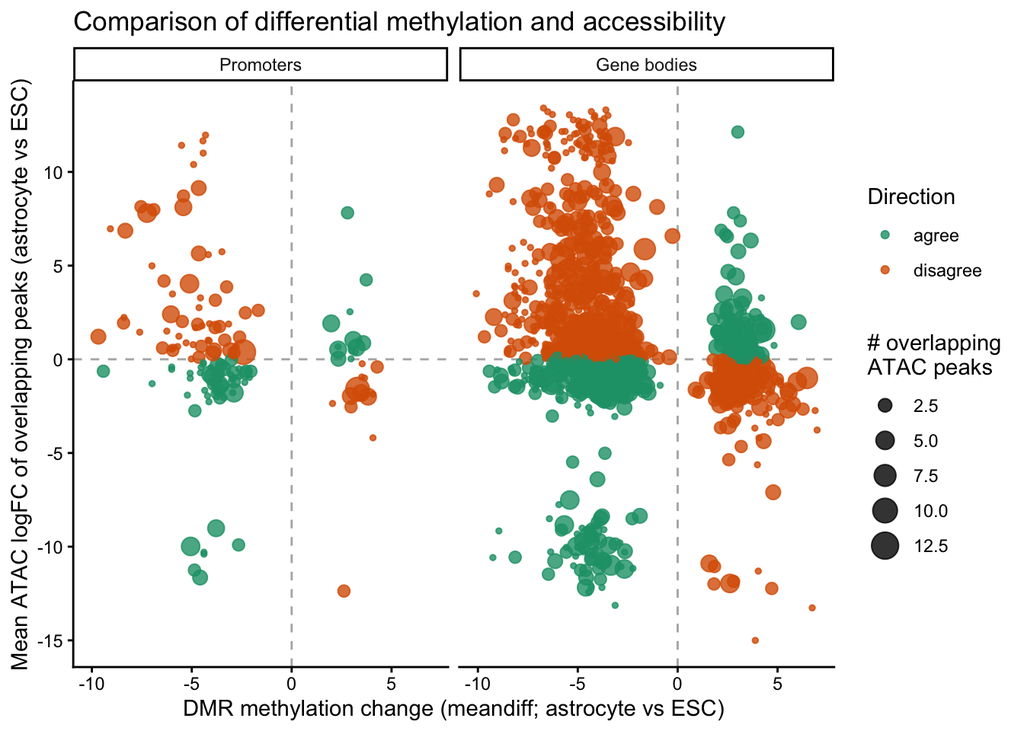

```r
ggplot(region_comp, aes(x=dmr_meandiff, y=atac_logFC_mean, color=signal_change, size=n_atac_peaks)) +
  geom_hline(yintercept=0, linetype="dashed", color="grey70") +
  geom_vline(xintercept=0, linetype="dashed", color="grey70") +
  geom_point(alpha=0.8) +
  scale_color_manual(values=c(agree="#1b9e77", disagree="#d95f02")) +
  facet_wrap(~region_type) +
  labs(
    x="DMR methylation change (meandiff; astrocyte vs ESC)",
    y="Mean ATAC logFC of overlapping peaks (astrocyte vs ESC)",
    color="Direction",
    size="# overlapping\nATAC peaks",
    title="Comparison of differential methylation and accessibility"
  ) +
  theme_classic()
```

The plots shos us that there seems to be some disagreement between methlation and accessibility both at the promoters where we would expect it and the gene bodies as well.

In gene bodies, the opposite effect of methylation and accessibility is more pronounced, with most points showing decreasing methylation co-occurring with increased accessibility. At promoters, there is also a tendency for opposite-direction changes, but there are more points showing agreement between methylation and accessibility changes compared to gene bodies.

```r
agree_summary <- as.data.frame(prop.table(table(region_comp$region_type, region_comp$signal_change), 1))
colnames(agree_summary) <- c("region_type", "direction", "fraction")
agree_summary
```

| region_type | direction | fraction |
| --- | --- | --- |
| Promoters | agree | 0.4718310 |
| Gene bodies | agree | 0.4017791 |
| Promoters | disagree | 0.5281690 |
| Gene bodies | disagree | 0.5982209 |

```r
region_metrics <- rbind(promoter_res$metrics, gene_body_res$metrics)
region_metrics
```

| region_type | pearson_cor | spearman_cor |
| --- | --- | --- |
| Promoters | -0.2180651 | -0.3487430 |
| Gene bodies | -0.2238904 | -0.3013527 |

Both correlation metrics show a negative correlation of methlyation and accessibility, which hints at (limited) exclusivity of signals.